# Tahapan Penelitian

## Outline

1. Tahapan Penelitian Umum
2. Tahapan Penelitian Computing
3. Tahapan Penelitian Computing Fokus Perbaikan Algoritma

## Tahapan Penelitian Umum

## Tahapan Penelitian Umum

1. Identifikasi Masalah
2. Perumusan Hipotesis
3. Pengujian Hipotesis dan Analisis
4. Kesimpulan

Hipotesis adalah jawaban atau dugaan sementara terhadap rumusan masalah penelitian yang kebenarannya masih harus diuji secara empiris. Hipotesis berasal dari bahasa Yunani, yaitu *hypo* = dibawah dan *thesis* = pendirian/pendapat.

Secara empiris adalah pendekatan berbasis bukti nyata, pengalaman langsung, atau pengamatan yang dapat diindra (dilihat, didengar, dirasakan) untuk memperoleh kebenaran.

## Tahapan Penelitian Umum vs Tesis

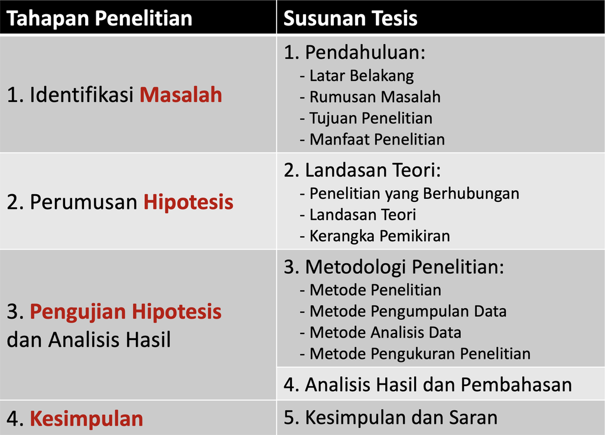

```r
knitr::include_graphics("img/m2/tahapan-penelitian.png")
```

## Tahapan Penelitian Computing

## Tahapan Penelitian Computing

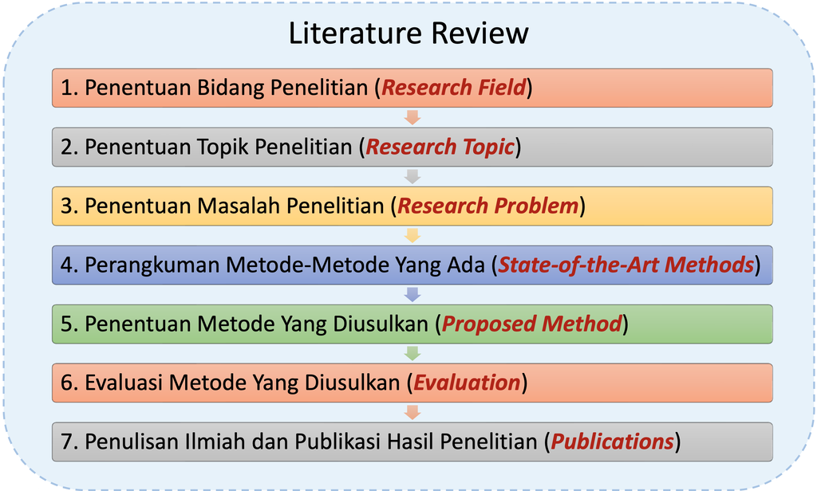

```r
knitr::include_graphics("img/m2/tahapan-penelitian-computing.png")
```

## Penentuan Bidang Penelitian

- Ingat kembali semua matakuliah yang telah dipelajari selama kuliah.
- Bidang penelitian di disiplin *komputer jaringan*:
  - Internet of Things (IoT): Penelitian tentang konektivitas perangkat pintar, protokol komunikasi ringan, dan manajemen data IoT.
  - Komputasi Awan (Cloud Computing) & Virtualisasi: Fokus pada efisiensi pusat data, virtualisasi jaringan, dan penyediaan layanan cloud yang handal.
  - Keamanan Jaringan & Siber (Cybersecurity): Mengembangkan deteksi intrusi, kriptografi, keamanan jaringan nirkabel, dan analisis forensik jaringan.

## Penentuan Bidang Penelitian

- Jaringan Nirkabel & Seluler (MANET, VANET, 5G/6G): Penelitian mengenai Mobile Ad-hoc Networks (MANET), jaringan sensor, dan optimasi jaringan nirkabel generasi berikutnya.
- Software-Defined Networking (SDN) & NFV: Pengelolaan jaringan berbasis perangkat lunak untuk fleksibilitas dan kontrol yang lebih baik.
- Manajemen & Optimalisasi Jaringan (QoS): Pengaturan bandwidth, pemantauan lalu lintas (traffic monitoring), dan Quality of Service (QoS) untuk performa optimal.
- Analisis Jaringan berbasis AI/ML: Penggunaan machine learning untuk prediksi lalu lintas, manajemen jaringan otomatis, dan deteksi ancaman cerdas.
- Teori Graf dalam Jaringan: Pemodelan dan optimasi topologi jaringan menggunakan konsep matematika graf.

## Penentuan Topik Penelitian

1. Searching di ScienceDirect.Com, Springerlink, IEEE Explore, Google (Scholar):
   - research trends challenge topics on NAMA BIDANG
2. Untuk mempercepat pembelajaran, temukan survey paper berbentuk Tertiery Study (SLR dari SLR), karena isinya sudah merangkumkan satu bidang penelitian
3. Lanjutkan penentuan topik penelitian dengan menemukan suvey/review paper (SLR, SMS), karena survey/review paper yang masuk jurnal terindeks pasti membahas satu topik penelitian

## Penentuan Masalah Penelitian

1. Searching di google, google scholar, ScienceDirect.Com:
   - Survey review on NAMA TOPIK
   - Research problem challenge on NAMA TOPIK
2. Dari “survey paper” yang ditemukan, kejar sampai dapat semua “technical paper” yang ada di daftar referensinya
3. Dari puluhan/ratusan/ribuan paper yang didapat lakukan scanning, pilih paper journal yang terindeks SCOPUS/ISI, 3 tahun terakhir, dan peta kan masalah penelitian yang ada di paper-paper itu
4. Gunakan Mendeley/Zotero untuk mempermudah pekerjaan kita
5. Pilih satu atau dua masalah penelitian yang kita anggap menarik dan menantang, dan jadikan itu masalah penelitian kita

## Perangkuman Metode Yang Ada

- Pahami semua paper penelitian yang tujuannya memecahkan masalah yang sama dengan yang kita pilih
- Pahami metode/algoritma terkini yang mereka gunakan untuk memecahkan masalah penelitian mereka. Ini yang disebut dengan state-of-the-art method
- Dalam bidang computing, metode biasanya berupa algoritma yang secara sistematis, logis dan matematis menyelesaikan masalah

## Penentuan Metode Yang Diusulkan

- Kita harus membangun dan mengusulkan suatu metode (proposed method), yg lebih baik bila dibandingkan dengan metode-metode yang ada saat ini
- Keunggulan metode yang kita usulkan harus dilandasi (reference), dibuktikan secara matematis dan empiris lewat hasil eksperimen dan perbandingan dengan metode yang ada
- Metode yang kita usulkan itu bisa saja dari state-of-the-art methods, kita kemudian “menambahkan” sesuatu (algoritma, koefisien, formula, dsb), yang akhirnya ketika kita bandingkan dengan metode original, metode kita lebih baik (lebih cepat, lebih akurat, lebih konsisten, dsb).
- “Penambahan” yang kita lakukan dan akhirnya membuat pemecahan masalah menjadi lebih baik itulah yang disebut dengan kontribusi ke pengetahuan (contribution to knowledge) (Dawson, 2009)

## Evaluasi Metode Yang Diusulkan

- Metode yang diusulkan harus divalidasi dan dievaluasi dengan metode pengukuran standard dan disepakati para peneliti di bidang penelitian yang kita lakukan
- Pengukuran metode disesuaikan dengan masalah dan tujuan penelitian:
  - Masalahnya rendahnya akurasi → pengukurannya akurasi
  - Masalah rendahnya efisiensi → pengukurannya waktu

## Penulisan Ilmiah dan Publikasi Hasil Penelitian

- Lakukan pendataan journal-journal yang ada di bidang kita, urutkan berdasarkan rangking SJR atau JIF
- Pilih target journal untuk tempat publikasi hasil penelitian kita
- Publikasikan hasil penelitian ke journal yang sesuai dengan kualitas kontribusi penelitian yang kita lakukan
- A paper is an organized description of hypotheses, data and conclusions, intended to instruct the reader. If your research does not generate papers, it might just as well not have been done (Whitesides 2004)

## Tugas

Cari jurnal-jurnal yang terakreditasi SINTA atau terindek SCOPUS dan tambahkan ke repository [awesome-journal-targets](https://github.com/muhdavi-pnl/awesome-journal-targets.git) dengan melakukan pull request melalui branch `national-journal` atau `international-journal`.